# Uso de la API del COVID19 con Pandas

Base de datos de interés, como URL y en formato JSON http://api.covid19api.com/countries

## Instalar las librerías con las que vamos a trabajar

Pandas es una librería estándar de python para el manejo de datos

Instalamos pandas con el comando `!pip install`, que es lenguaje de python

```python
!pip install pandas
```

## Configuración de Pandas

Importamos la librería pandas y la renombramos como "pd" para utilizarla en el resto del notebook

```python
import pandas as pd
```

## Creación de variables

Creamos una variable que contiene la base de datos que vamos a usar mediante `=`

```python
url = 'https://api.covid19api.com/countries'
```

## Creación del Dataframe

Creamos un dataframe de pandas leyendo el JSON de la base de datos

Según la [documentación oficial de pandas](https://pandas.pydata.org/docs/reference/api/pandas.DataFrame.html), un dataframe es una estructura de datos de dos dimensiones "de tamaño variable y potencialmente heterogéneos".

Un JSON, según hemos visto en la asignatura, es un tipo de familia de datos. Concretamente, JSON es una notación de objetos en Javascript.

```python
df = pd.read_json(url)
```

## Mostramos la tabla

Introduciendo df (que es como hemos nombrado al datafrmae), mostramos la tabla

```python
df
```

|  | Country | Slug | ISO2 |
| --- | --- | --- | --- |
| 0 | Honduras | honduras | HN |
| 1 | Nicaragua | nicaragua | NI |
| 2 | Tunisia | tunisia | TN |
| 3 | Gibraltar | gibraltar | GI |
| 4 | South Georgia and the South Sandwich Islands | south-georgia-and-the-south-sandwich-islands | GS |
| ... | ... | ... | ... |
| 243 | Holy See (Vatican City State) | holy-see-vatican-city-state | VA |
| 244 | Lesotho | lesotho | LS |
| 245 | Norfolk Island | norfolk-island | NF |
| 246 | Palau | palau | PW |
| 247 | Wallis and Futuna Islands | wallis-and-futuna-islands | WF |

248 rows × 3 columns

## Exploración de la tabla

#### Cabecera

Mediante `df.head()` se muestran las primeras entradas de la tabla (cabecera o head), entre paréntesis se pueden indicar cuántas entradas se quieren mostrar

```python
df.head()
```

|  | Country | Slug | ISO2 |
| --- | --- | --- | --- |
| 0 | Honduras | honduras | HN |
| 1 | Nicaragua | nicaragua | NI |
| 2 | Tunisia | tunisia | TN |
| 3 | Gibraltar | gibraltar | GI |
| 4 | South Georgia and the South Sandwich Islands | south-georgia-and-the-south-sandwich-islands | GS |

#### Tail de la tabla

Ahora se muestran las últimas entradas de la tabla (tail) mediante `df.tail()`

De nuevo, entre paréntesis se puede espeficiar el número de entradas que se quieren mostrar. En este caso se muestran dos

```python
df.tail(2)
```

|  | Country | Slug | ISO2 |
| --- | --- | --- | --- |
| 246 | Palau | palau | PW |
| 247 | Wallis and Futuna Islands | wallis-and-futuna-islands | WF |

#### Mostramos la información de la tabla como objeto de pandas

Mediante `df.info()` se muestra la información de la tabla

```python
df.info()
```

```
<class 'pandas.core.frame.DataFrame'>
RangeIndex: 248 entries, 0 to 247
Data columns (total 3 columns):
 #   Column   Non-Null Count  Dtype
---  ------   --------------  -----
 0   Country  248 non-null    object
 1   Slug     248 non-null    object
 2   ISO2     248 non-null    object
dtypes: object(3)
memory usage: 5.9+ KB
```

#### Mostramos la columna Country

`df[]` permite mostrar una columna del datafram en concreto. En este caso se ha elegido la columna de los países, "Country":

```python
df['Country']
```

```
0                                          Honduras
1                                         Nicaragua
2                                           Tunisia
3                                         Gibraltar
4      South Georgia and the South Sandwich Islands
                           ...
243                   Holy See (Vatican City State)
244                                         Lesotho
245                                  Norfolk Island
246                                           Palau
247                       Wallis and Futuna Islands
Name: Country, Length: 248, dtype: object
```

Mostramos la fila 66 de la fila Country

```python
df['Country'][66]
```

```
'Western Sahara'
```

## Tiempo real

Empleamos la base de datos siguiente https://api.covid19api.com/country/spain/status/confirmed/live

Como se puede ver, se trata de una API, que como hemos visto en clase es una interfaz de programación de acceso o Assist Programming Interface. Una APII muy reconocida es http.

### Definimos variables

Como ya hemos hecho en otras ocasiones, a continuación definimos unas nuevas variables mediante `=`, para la que se necesita la base de datos que se acaba de mencionar.

Definimos la varibale `url_es`, en la que se encuentran los datos para España, y la variable `df_es` que hace referencia al nuevo dataframe que se va a crear para los datos de España

A continuación, mediante mostramos el dataframe o tabla poniendo `df_es`, esta vez sin el igual

```python
url_es = 'https://api.covid19api.com/country/spain/status/confirmed/live'
df_es = pd.read_json(url_es)
df_es
```

|  | Country | CountryCode | Province | City | CityCode | Lat | Lon | Cases | Status | Date |
| --- | --- | --- | --- | --- | --- | --- | --- | --- | --- | --- |
| 0 | Spain | ES |  |  |  | 40.46 | -3.75 | 0 | confirmed | 2020-01-22 00:00:00+00:00 |
| 1 | Spain | ES |  |  |  | 40.46 | -3.75 | 0 | confirmed | 2020-01-23 00:00:00+00:00 |
| 2 | Spain | ES |  |  |  | 40.46 | -3.75 | 0 | confirmed | 2020-01-24 00:00:00+00:00 |
| 3 | Spain | ES |  |  |  | 40.46 | -3.75 | 0 | confirmed | 2020-01-25 00:00:00+00:00 |
| 4 | Spain | ES |  |  |  | 40.46 | -3.75 | 0 | confirmed | 2020-01-26 00:00:00+00:00 |
| ... | ... | ... | ... | ... | ... | ... | ... | ... | ... | ... |
| 814 | Spain | ES |  |  |  | 40.46 | -3.75 | 11627487 | confirmed | 2022-04-15 00:00:00+00:00 |
| 815 | Spain | ES |  |  |  | 40.46 | -3.75 | 11627487 | confirmed | 2022-04-16 00:00:00+00:00 |
| 816 | Spain | ES |  |  |  | 40.46 | -3.75 | 11627487 | confirmed | 2022-04-17 00:00:00+00:00 |
| 817 | Spain | ES |  |  |  | 40.46 | -3.75 | 11627487 | confirmed | 2022-04-18 00:00:00+00:00 |
| 818 | Spain | ES |  |  |  | 40.46 | -3.75 | 11627487 | confirmed | 2022-04-19 00:00:00+00:00 |

819 rows × 10 columns

#### Nombres de las columnas de la tabla

Se puede mostrar el nombre de las columnas de la tabla mediante `.columns` y añadiendo delante el nombre del data frame (que es `df_es`). Por lo tanto, para mostrar los datos de este dataframe se debe poner `df_es.columns`

```python
df_es.columns
```

```
Index(['Country', 'CountryCode', 'Province', 'City', 'CityCode', 'Lat', 'Lon',
       'Cases', 'Status', 'Date'],
      dtype='object')
```

#### Columna Date

También se pueden mostrar columnas en concreto mediante `df['nombre de la columna']`

A continuación se ejemplifica con la columna "Date", aunque únicamente se muestra la primera fila (1) por la cabecera (head)

```python
df_es['Date'].head(1)
```

```
0   2020-01-22 00:00:00+00:00
Name: Date, dtype: datetime64[ns, UTC]
```

Mostramos la primera fila (1) por el final de tabla (tail) de la columna Date

```python
df_es['Date'].tail(1)
```

```
818   2022-04-19 00:00:00+00:00
Name: Date, dtype: datetime64[ns, UTC]
```

#### Mostramos información sobre la tabla

```python
df_es.info()
```

```
<class 'pandas.core.frame.DataFrame'>
RangeIndex: 819 entries, 0 to 818
Data columns (total 10 columns):
 #   Column       Non-Null Count  Dtype
---  ------       --------------  -----
 0   Country      819 non-null    object
 1   CountryCode  819 non-null    object
 2   Province     819 non-null    object
 3   City         819 non-null    object
 4   CityCode     819 non-null    object
 5   Lat          819 non-null    float64
 6   Lon          819 non-null    float64
 7   Cases        819 non-null    int64
 8   Status       819 non-null    object
 9   Date         819 non-null    datetime64[ns, UTC]
dtypes: datetime64[ns, UTC](1), float64(2), int64(1), object(6)
memory usage: 64.1+ KB
```

#### Muestra variables estadísticas de la tabla (de las columnas numéricas)

Mediante `df_es.describe()` se muestran las variables estadísticas del dataframe, algo que no se muestra normalmente

```python
df_es.describe()
```

|  | Lat | Lon | Cases |
| --- | --- | --- | --- |
| count | 8.190000e+02 | 819.00 | 8.190000e+02 |
| mean | 4.046000e+01 | -3.75 | 3.405791e+06 |
| std | 1.421954e-14 | 0.00 | 3.289907e+06 |
| min | 4.046000e+01 | -3.75 | 0.000000e+00 |
| 25% | 4.046000e+01 | -3.75 | 3.400735e+05 |
| 50% | 4.046000e+01 | -3.75 | 3.178356e+06 |
| 75% | 4.046000e+01 | -3.75 | 4.949120e+06 |
| max | 4.046000e+01 | -3.75 | 1.162749e+07 |

Mostramos el dataframe

```python
df_es
```

|  | Country | CountryCode | Province | City | CityCode | Lat | Lon | Cases | Status | Date |
| --- | --- | --- | --- | --- | --- | --- | --- | --- | --- | --- |
| 0 | Spain | ES |  |  |  | 40.46 | -3.75 | 0 | confirmed | 2020-01-22 00:00:00+00:00 |
| 1 | Spain | ES |  |  |  | 40.46 | -3.75 | 0 | confirmed | 2020-01-23 00:00:00+00:00 |
| 2 | Spain | ES |  |  |  | 40.46 | -3.75 | 0 | confirmed | 2020-01-24 00:00:00+00:00 |
| 3 | Spain | ES |  |  |  | 40.46 | -3.75 | 0 | confirmed | 2020-01-25 00:00:00+00:00 |
| 4 | Spain | ES |  |  |  | 40.46 | -3.75 | 0 | confirmed | 2020-01-26 00:00:00+00:00 |
| ... | ... | ... | ... | ... | ... | ... | ... | ... | ... | ... |
| 814 | Spain | ES |  |  |  | 40.46 | -3.75 | 11627487 | confirmed | 2022-04-15 00:00:00+00:00 |
| 815 | Spain | ES |  |  |  | 40.46 | -3.75 | 11627487 | confirmed | 2022-04-16 00:00:00+00:00 |
| 816 | Spain | ES |  |  |  | 40.46 | -3.75 | 11627487 | confirmed | 2022-04-17 00:00:00+00:00 |
| 817 | Spain | ES |  |  |  | 40.46 | -3.75 | 11627487 | confirmed | 2022-04-18 00:00:00+00:00 |
| 818 | Spain | ES |  |  |  | 40.46 | -3.75 | 11627487 | confirmed | 2022-04-19 00:00:00+00:00 |

819 rows × 10 columns

#### Indexar el dataframe según una columna

También es posible indexar -ordenar los datos- en función de una columna mediante `df.set_index('')`

En este caso, se indexa el dataframe según la columna "Date"

```python
df_es.set_index('Date')
```

| Date | Country | CountryCode | Province | City | CityCode | Lat | Lon | Cases | Status |
| --- | --- | --- | --- | --- | --- | --- | --- | --- | --- |
| 2020-01-22 00:00:00+00:00 | Spain | ES |  |  |  | 40.46 | -3.75 | 0 | confirmed |
| 2020-01-23 00:00:00+00:00 | Spain | ES |  |  |  | 40.46 | -3.75 | 0 | confirmed |
| 2020-01-24 00:00:00+00:00 | Spain | ES |  |  |  | 40.46 | -3.75 | 0 | confirmed |
| 2020-01-25 00:00:00+00:00 | Spain | ES |  |  |  | 40.46 | -3.75 | 0 | confirmed |
| 2020-01-26 00:00:00+00:00 | Spain | ES |  |  |  | 40.46 | -3.75 | 0 | confirmed |
| ... | ... | ... | ... | ... | ... | ... | ... | ... | ... |
| 2022-04-15 00:00:00+00:00 | Spain | ES |  |  |  | 40.46 | -3.75 | 11627487 | confirmed |
| 2022-04-16 00:00:00+00:00 | Spain | ES |  |  |  | 40.46 | -3.75 | 11627487 | confirmed |
| 2022-04-17 00:00:00+00:00 | Spain | ES |  |  |  | 40.46 | -3.75 | 11627487 | confirmed |
| 2022-04-18 00:00:00+00:00 | Spain | ES |  |  |  | 40.46 | -3.75 | 11627487 | confirmed |
| 2022-04-19 00:00:00+00:00 | Spain | ES |  |  |  | 40.46 | -3.75 | 11627487 | confirmed |

819 rows × 9 columns

Muestra la columna Cases una vez se ha indexado la tabla por Date, y muestra esta columna junto a su índice

```python
df_es.set_index('Date')['Cases']
```

```
Date
2020-01-22 00:00:00+00:00           0
2020-01-23 00:00:00+00:00           0
2020-01-24 00:00:00+00:00           0
2020-01-25 00:00:00+00:00           0
2020-01-26 00:00:00+00:00           0
                               ...
2022-04-15 00:00:00+00:00    11627487
2022-04-16 00:00:00+00:00    11627487
2022-04-17 00:00:00+00:00    11627487
2022-04-18 00:00:00+00:00    11627487
2022-04-19 00:00:00+00:00    11627487
Name: Cases, Length: 819, dtype: int64
```

#### Nombrar y crear el gráfico a partir del dataframe

Una vez indexados los datos según "Date" y "Cases", mediante `.plot` se muestran los datos en un gráfico

Añadiendo `title=` como argumento de .plot se pone un título al gráfico

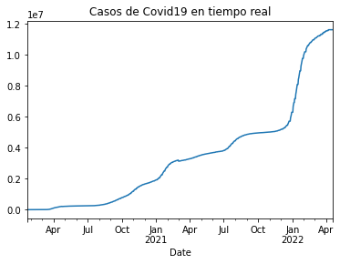

```python
df_es.set_index('Date')['Cases'].plot(title="Casos de Covid19 en tiempo real")
```

# Otro país

Definimos nuevas variables, esta vez para el país Italia, y creamos un dataframe para este país

A continuación creamos un gráfico mediante `.plot` a partir del dataframe

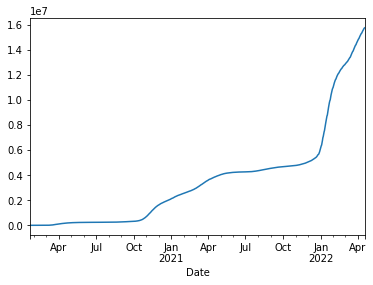

```python
url_it = 'https://api.covid19api.com/country/italy/status/confirmed/live'
df_it = pd.read_json(url_it)
df_it.set_index('Date')['Cases'].plot()
```

## Comparación

Comparamos estos dos países en un solo gráfico para poder observar las diferencias entre los casos y las fechas de COVID-19 en los dos países (España e Italia)

Para ello definimos dos variables mediante `casos_es` para los datos de España, y `casos_it` para los datos italianos

```python
casos_es = df_es.set_index('Date')['Cases']
casos_it = df_it.set_index('Date')['Cases']
```

#### Concatenamos ambos casos

Antes de crear un dataframe y un gráfico con estos datos, es necesario concatearlos mediante 'vs' para que se muestren en una sola tabla

```python
vs = pd.concat([casos_es,casos_it],axis=1)
vs
```

| Date | Cases | Cases |
| --- | --- | --- |
| 2020-01-22 00:00:00+00:00 | 0 | 0 |
| 2020-01-23 00:00:00+00:00 | 0 | 0 |
| 2020-01-24 00:00:00+00:00 | 0 | 0 |
| 2020-01-25 00:00:00+00:00 | 0 | 0 |
| 2020-01-26 00:00:00+00:00 | 0 | 0 |
| ... | ... | ... |
| 2022-04-15 00:00:00+00:00 | 11627487 | 15595302 |
| 2022-04-16 00:00:00+00:00 | 11627487 | 15659835 |
| 2022-04-17 00:00:00+00:00 | 11627487 | 15712088 |
| 2022-04-18 00:00:00+00:00 | 11627487 | 15730676 |
| 2022-04-19 00:00:00+00:00 | 11627487 | 15758002 |

819 rows × 2 columns

### Creamos el gráfico

Creamos un gráfico que una los dos casos

Para ello necesitamos marcar la concatenación de los datos de España e Italia mediante `vs.columns` y a continuación creamos la tabla a partir de esta concatenación `vs.plot`. Aquí también definimos el título de la tabla como "España vs Itlia" mediante el argumento `title`

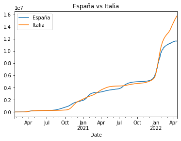

```python
vs.columns =['España', 'Italia']
vs.plot(title="España vs Italia")
```

### Guardamos en un csv

Para guardar todo lo realizado en un csv, es necesario poner `vs.to_csv`

```python
vs.to_csv('esvit.csv')
```

Comprobamos que el archivo se ha creado

Para ello, necesitamos usar `!` que nos permite emplear en Jupyter un comando de la terminal, concretamente el comando `ls`, que sirve para saber qué tienes en un lugar concreto

```python
!ls
```

```
api-pandas-folium.ipynb  probando-con-r.ipynb		  seaborn-data
escit.png		 python-api-covid19-pandas.ipynb  Shared_Resources
esvit.csv		 python-pruebas.ipynb
```

Importamos matplotlib.pyplot y lo redefinimos como plt

Por último, guardamos el gráfico mediante `plt.savefig()`

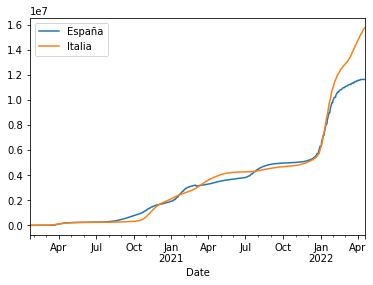

```python
import matplotlib.pyplot as plt
vs.plot()
plt.savefig('escit.png')
```